# BIOS611 P1

Lu Xu

9/24/2018

```r
library(tidyverse)
```

## USArrests

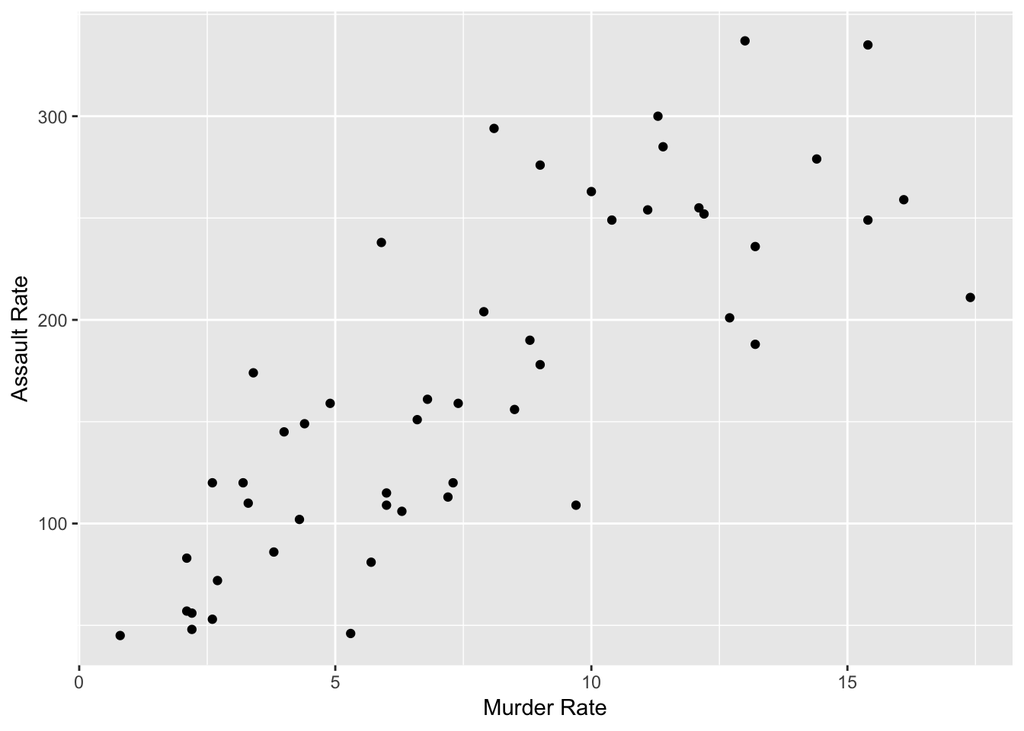

```r
ggplot(data = USArrests, mapping = aes(x=Murder, y=Assault)) +
  geom_point() +
  xlab('Murder Rate') +
  ylab('Assault Rate')
```

```r
murder_low = filter(USArrests, Murder < 4.0)
murder_low$Murder
```

```
##  [1] 3.3 2.6 2.2 2.1 2.7 2.1 0.8 3.4 3.8 3.2 2.2 2.6
```

This figure was derived from the “USArrests” data set in R, which is derived from “World Almanac and Book of facts 1975. (Crime rates)”. This data set contains statistics, in arrests per 100,000 residents for assault, murder, and rape in each of the 50 US states in 1973. Also given is the percent of the population living in urban areas.

As a next step, it would be interesting to look at the relationship between murder and assault rate, but actually simulate a linear regression model for each two of the variables, and see how the relationship between them.

## PlantGrowth

```r
data("PlantGrowth")
summary(PlantGrowth)
```

```
##      weight       group
##  Min.   :3.590   ctrl:10
##  1st Qu.:4.550   trt1:10
##  Median :5.155   trt2:10
##  Mean   :5.073
##  3rd Qu.:5.530
##  Max.   :6.310
```

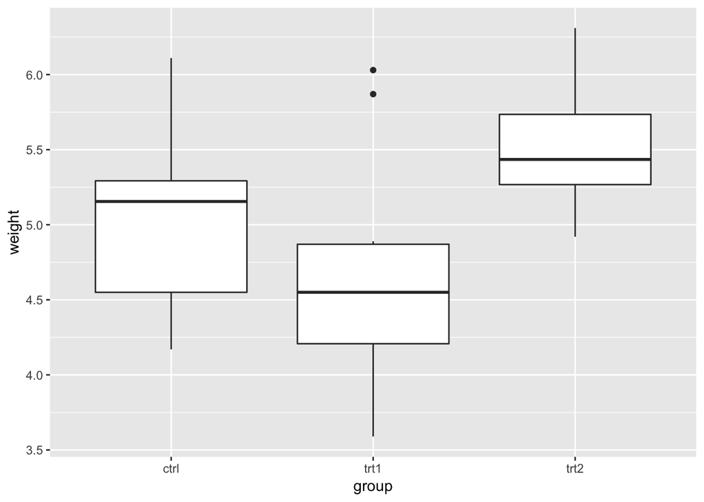

```r
tp2 = as.tibble(PlantGrowth)
tp2$names = names(PlantGrowth)

ggplot(data = tp2, mapping = aes(x=group, y=weight)) +
  geom_boxplot()
```

```r
ctr1_low = filter(PlantGrowth, weight < 4.00)
ctr1_low
```

```
##   weight group
## 1   3.59  trt1
## 2   3.83  trt1
```

This figure was derived from the “PlantGrowthp” data set in R, which is derived from “Dobson, A. J. (1983) An Introduction to Statistical Modelling. London: Chapman and Hall.”. It results from an experiment to compare yields (as measured by dried weight of plants) obtained under a control and two different treatment conditions. The mean weight of three group is 5.073. The minimum weight is 3.590 and maxium weight is 6.310.

As a next step, it would be interesting to look at more than just the average of three groups, but actually see the distribution for each group, and compare the difference of them.